# Notebook 12 – Solutions

## Getting Started

Before running this notebook, select “Session > Restart R and Clear Output” in the menu above to start a new R session. This will clear any old data sets and give us a blank slate to start with.

## Movies Data

Over the next few classes we will be working with a dataset of movies I have constructed consisting of the top 100 grossing films for each year from 1970 to 2019. The data comes from IMDb. Today we will focus on getting familiar with the various components of the data. Let’s read in the four tables of data, as well as a data dictionary, and then go through each of the tables.

```r
movies <- read_csv(file.path("data", "movies_50_years.csv"))
m_genre <- read_csv(file.path("data", "movies_50_years_genre.csv"))
m_people <- read_csv(file.path("data", "movies_50_years_people.csv"))
m_dict <- read_csv(file.path("data", "movies_50_years_data_dictionary.csv"))
m_color <- read_csv(file.path("data", "movies_50_years_color.csv"))
```

See notebook11 and the data dictionary for more information about the available variables.

### Movie People

Summarize the average number of people listed as starring in a film for each year (first count the number per film and then take the average), and plot the pattern over the 50 years of data that we have available to us. Do you notice anything strange about the dataset?

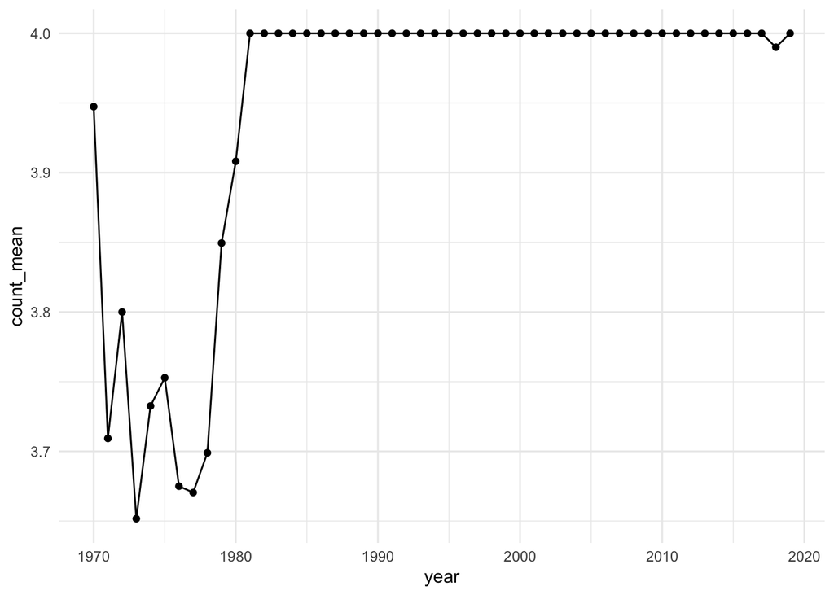

```r
m_people %>%
  filter(role == "starring") %>%
  group_by(year, title) %>%
  summarize(sm_count()) %>%
  summarize(sm_mean(count)) %>%
  ggplot(aes(year, count_mean)) +
    geom_point() +
    geom_line()
```

Filter the data to those names where the gender confidence score is less than 0.6. Note any patterns that you see and consider caveats that any gender-based analysis on the larger dataset should consider.

```r
m_people %>%
  filter(gender_conf < 0.6)
```

```
## # A tibble: 206 x 7
##     year title                    role     rank person     gender gender_conf
##    <dbl> <chr>                    <chr>   <dbl> <chr>      <chr>        <dbl>
##  1  1970 Le casse de l'oncle Tom  direct…     1 Ossie Dav… female       0.521
##  2  1970 The Hawaiians            starri…     4 Mako       female       0.514
##  3  1970 How Do I Love Thee?      starri…     1 Jackie Gl… female       0.554
##  4  1970 Multiple Maniacs         starri…     1 Divine     female       0.569
##  5  1970 Scent of Love            starri…     4 Casey Lar… male         0.575
##  6  1971 Nympho Cycler            starri…     1 Casey Lar… male         0.575
##  7  1971 The Secretary            starri…     3 Jeryl Hen… female       0.593
##  8  1972 Pink Flamingos           starri…     1 Divine     female       0.569
##  9  1972 The Gospel According to… starri…     1 Blair Zyk… male         0.503
## 10  1972 The Young Rounders       direct…     1 Casey Tib… male         0.575
## # … with 196 more rows
```

Now, make a plot showing the number of films starring the 20 most prolific actors with the bars filled according to an actor’s gender. Note, consider grouping the data by both gender and person before doing the summarization.

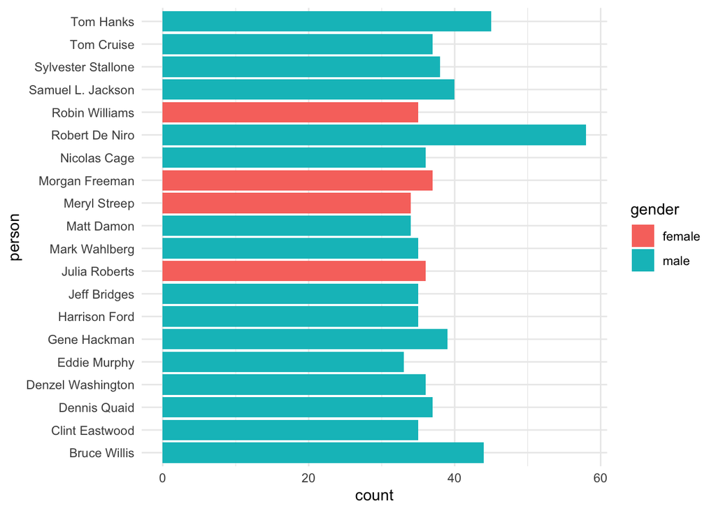

```r
m_people %>%
  filter(role == "starring") %>%
  group_by(gender, person) %>%
  summarize(sm_count()) %>%
  arrange(desc(count)) %>%
  ungroup() %>%
  slice(1:20) %>%
  ggplot(aes(person, count)) +
    geom_col(aes(fill = gender)) +
    coord_flip()
```

You will (hopefully) notice something strange in the plot above. Fix this by only including actors with a high gender confidence score (above 0.95 perhaps?).

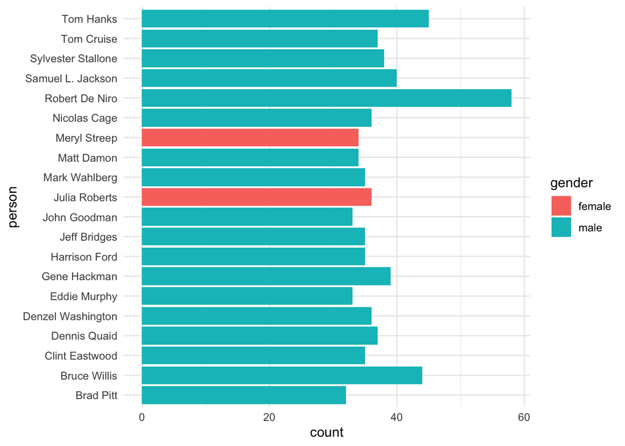

```r
m_people %>%
  filter(role == "starring") %>%
  filter(gender_conf > 0.95) %>%
  group_by(gender, person) %>%
  summarize(sm_count()) %>%
  arrange(desc(count)) %>%
  ungroup() %>%
  slice(1:20) %>%
  ggplot(aes(person, count)) +
    geom_col(aes(fill = gender)) +
    coord_flip()
```

### Movies Table

Start by plotting the average number of ratings (`rating_count`) for each year of the dataset. What patterns do you notice?

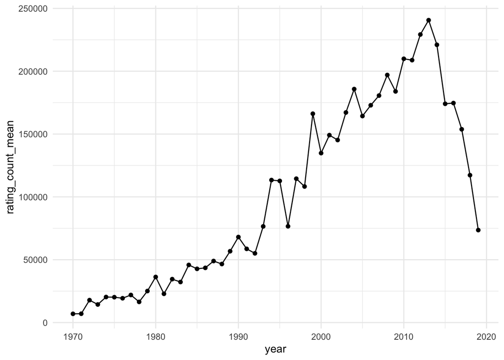

```r
movies %>%
  group_by(year) %>%
  summarize(sm_mean(rating_count)) %>%
  ggplot(aes(year, rating_count_mean)) +
    geom_line() +
    geom_point()
```

It will be helpful for some analyses to have a variable called `decade` in the dataset, because year may be too grainular to use. In the code below, create a decade variable using the variable `year` (i.e., 1972 => 1970, 1996 => 1990) and the function `floor`, which removes the decimal part of the year. Using floor, you can get decade with a few basic mathematical operations. Once you are confident your code is correct, add this variable into our copy of the `movies` dataset.

```r
movies <- movies %>%
  mutate(decade = floor(year / 10) * 10)
```

Create a confidence interval (`sm_mean_cl_normal`) showing the average rating of films for each year of the dataset and plot these with `geom_pointrange` with year on the x-axis. Do you notice a trend? Do you find it hard to find the trend in the data?

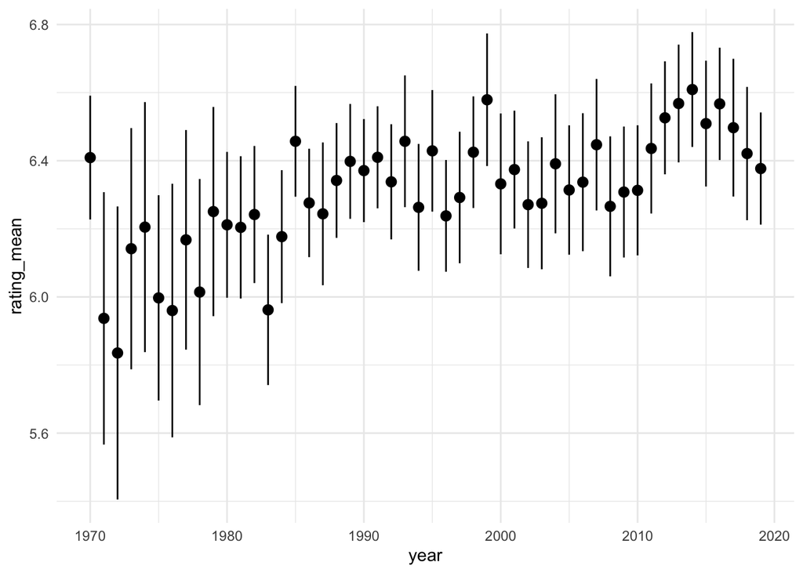

```r
movies %>%
  group_by(year) %>%
  summarize(sm_mean_cl_normal(rating)) %>%
  ggplot(aes(year, rating_mean)) +
    geom_pointrange(aes(ymin = rating_ci_min, ymax = rating_ci_max))
```

Repeat the previous task, but group by decade in place of year. You should find this easier to read, and find that the confidence intervals are smaller due to the larger amount of data for each point.

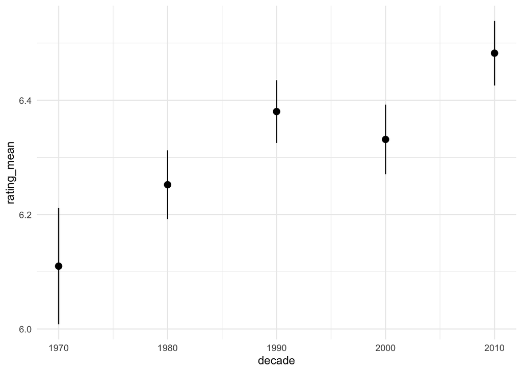

```r
movies %>%
  group_by(decade) %>%
  summarize(sm_mean_cl_normal(rating)) %>%
  ggplot(aes(decade, rating_mean)) +
    geom_pointrange(aes(ymin = rating_ci_min, ymax = rating_ci_max))
```

Select the top grossing film from each year. Scroll through the list; how many of these films do you know (approximately, no need to formally count)?

```r
movies %>%
  group_by(year) %>%
  slice(1)
```

```
## # A tibble: 50 x 13
## # Groups:   year [50]
##     year title mpa   runtime gross rating_count rating metacritic
##    <dbl> <chr> <chr>   <dbl> <dbl>        <dbl>  <dbl>      <dbl>
##  1  1970 Love… PG        100  106.        28330    6.9         NA
##  2  1971 Bill… GP        114   98          5320    6.3         50
##  3  1972 The … R         175  135.      1511801    9.2         NA
##  4  1973 The … R         122  233.       345980    8           NA
##  5  1974 Blaz… R          93  120.       119807    7.7         NA
##  6  1975 Jaws  PG        124  260        523455    8           NA
##  7  1976 Rocky PG        120  117.       491741    8.1         NA
##  8  1977 Star… PG        121  323.      1173923    8.6         NA
##  9  1978 Grea… PG-13     110  189.       222207    7.2         NA
## 10  1979 Kram… PG        105  106.       124324    7.8         NA
## # … with 40 more rows, and 5 more variables: poster_brightness <dbl>,
## #   poster_saturation <dbl>, poster_edgeness <dbl>, description <chr>,
## #   decade <dbl>
```

Now, take the 25th highest-gross film in each year (Note: NOT The films 1-25, just the 25th, so one film per year). How familiar are these? Do you know some decade better than others?

```r
movies %>%
  group_by(year) %>%
  slice(25)
```

```
## # A tibble: 50 x 13
## # Groups:   year [50]
##     year title mpa   runtime gross rating_count rating metacritic
##    <dbl> <chr> <chr>   <dbl> <dbl>        <dbl>  <dbl>      <dbl>
##  1  1970 The … R         121  3.5          8076    7.2         NA
##  2  1971 Hone… R          85  0.38          484    2.7         NA
##  3  1972 Boot… <NA>       NA NA               0   NA           NA
##  4  1973 The … R         112  0.96        23693    7.6         NA
##  5  1974 Thre… R          89  1.28         1044    6.3         NA
##  6  1975 Give… PG        104 11             424    7.2         NA
##  7  1976 Cann… R          93  3.27         4057    5.5         NA
##  8  1977 King… PG         97 17            4265    5.8         NA
##  9  1978 Good… PG         95 18.3          2635    5.1         NA
## 10  1979 Norm… PG        114 22.2          9785    7.3         NA
## # … with 40 more rows, and 5 more variables: poster_brightness <dbl>,
## #   poster_saturation <dbl>, poster_edgeness <dbl>, description <chr>,
## #   decade <dbl>
```

And finally, repeat with the 100th highest gross film in each year. Keep in mind how common (or not) these films seem to you as we work through the remainder of the dataset.

```r
movies %>%
  group_by(year) %>%
  slice(100)
```

```
## # A tibble: 50 x 13
## # Groups:   year [50]
##     year title mpa   runtime gross rating_count rating metacritic
##    <dbl> <chr> <chr>   <dbl> <dbl>        <dbl>  <dbl>      <dbl>
##  1  1970 Moth… <NA>       NA    NA            0   NA           NA
##  2  1971 Miss… <NA>       88    NA            5    6.4         NA
##  3  1972 Forb… <NA>       84    NA            6    7.2         NA
##  4  1973 Star… G          90    NA           21    5.2         NA
##  5  1974 Teen… R          NA    NA           20    6           NA
##  6  1975 Rime… Not …      60    NA           48    7.6         NA
##  7  1976 Kill… <NA>       89    NA           18    3.7         NA
##  8  1977 Pass… <NA>      105    NA           40    7.2         NA
##  9  1978 Imág… <NA>       NA    NA            0   NA           NA
## 10  1979 Evid… <NA>       90    NA           15    7           NA
## # … with 40 more rows, and 5 more variables: poster_brightness <dbl>,
## #   poster_saturation <dbl>, poster_edgeness <dbl>, description <chr>,
## #   decade <dbl>
```